# PCIT-CoS-Waitlist RCT Paper 1: Child Attention (NICHD), Controlling for ASD

Nancy Briggs

05 JAN 2021

### Child Attention (NICHD) Adjusting for ASD

#### Descriptives

Raw Data

| asdcase | group | time | n | mean | sd | median | min | max |
| --- | --- | --- | --- | --- | --- | --- | --- | --- |
| 0 | 1 | 1 | 23 | 15.109 | 2.663 | 16.0 | 10 | 20 |
| 0 | 1 | 2 | 18 | 14.944 | 3.058 | 14.5 | 8 | 19 |
| 0 | 1 | 3 | 12 | 17.667 | 2.902 | 18.0 | 10 | 20 |
| 0 | 2 | 1 | 25 | 14.653 | 2.849 | 14.0 | 10 | 20 |
| 0 | 2 | 2 | 10 | 15.600 | 2.459 | 15.5 | 12 | 19 |
| 0 | 2 | 3 | 4 | 17.500 | 2.380 | 18.5 | 14 | 19 |
| 0 | 3 | 1 | 22 | 15.055 | 3.253 | 15.5 | 7 | 19 |
| 0 | 3 | 2 | 17 | 15.624 | 2.817 | 16.6 | 11 | 19 |
| 0 | 3 | 3 | 0 | NaN | NA | NA | Inf | -Inf |
| 1 | 1 | 1 | 6 | 14.500 | 2.665 | 15.0 | 10 | 17 |
| 1 | 1 | 2 | 3 | 15.667 | 3.215 | 17.0 | 12 | 18 |
| 1 | 1 | 3 | 4 | 16.250 | 1.500 | 16.0 | 15 | 18 |
| 1 | 2 | 1 | 3 | 12.333 | 4.041 | 13.0 | 8 | 16 |
| 1 | 2 | 2 | 2 | 17.000 | 4.243 | 17.0 | 14 | 20 |
| 1 | 2 | 3 | 0 | NaN | NA | NA | Inf | -Inf |
| 1 | 3 | 1 | 5 | 13.000 | 3.536 | 13.0 | 9 | 17 |
| 1 | 3 | 2 | 4 | 14.500 | 2.646 | 14.0 | 12 | 18 |
| 1 | 3 | 3 | 0 | NaN | NA | NA | Inf | -Inf |

Note:  
One person the Waitlist has a value at Follow Up. It has been set to missing.

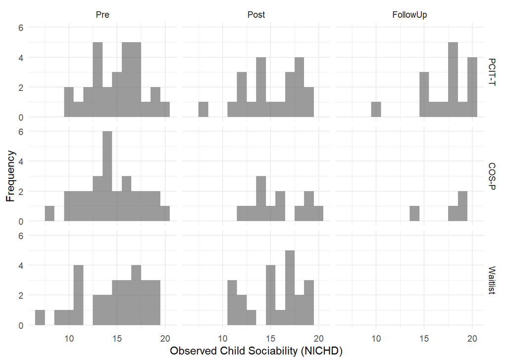

#### Model & Results

A linear mixed model with random effect for individual and fixed effects of group, time and the interaction was run. ASD status was then entered into the model as a main effect and then the 3-way interaction. Estimated marginal means were obtained, and contrasts specified to test Hypothesis 1 and Hypothesis 2.

```
## fixed-effect model matrix is rank deficient so dropping 1 column / coefficient
```

```
## fixed-effect model matrix is rank deficient so dropping 3 columns / coefficients
```

This is the ANOVA table for the model. p-values are likelihood ratio tests for adding the new term to the model just before. A p-value <0.05 indicates that adding that term results in better model fit. The most important p-value is the interaction p-value.

```
## refitting model(s) with ML (instead of REML)
```

[output not shown]

There is no evidence that ASD moderates the 2-way group*time interaction (the 3-way interaction p=0.701).

Model3, the model with Group*Time, adjusted by ASD will be the model I use for Estimated Means.

```r
summary(result3)
```

```
## Linear mixed model fit by REML. t-tests use Satterthwaite's method [
## lmerModLmerTest]
## Formula: outcome ~ asdcase + group * time + (1 | id)
##    Data: dat
##
## REML criterion at convergence: 760.9
##
## Scaled residuals:
##      Min       1Q   Median       3Q      Max
## -2.50295 -0.56151  0.02524  0.68317  1.72635
##
## Random effects:
##  Groups   Name        Variance Std.Dev.
##  id       (Intercept) 1.696    1.302
##  Residual             6.628    2.574
## Number of obs: 158, groups:  id, 86
##
## Fixed effects:
##               Estimate Std. Error        df t value Pr(>|t|)
## (Intercept)   15.18330    0.55393 137.60380  27.410  < 2e-16 ***
## asdcase1      -0.96927    0.67989  67.27905  -1.426  0.15860
## group2        -0.66529    0.76709 141.55842  -0.867  0.38725
## group3        -0.36471    0.77146 141.85178  -0.473  0.63711
## time2         -0.06369    0.74994  80.00874  -0.085  0.93253
## time3          2.18155    0.82289  86.67852   2.651  0.00954 **
## group2:time2   1.63859    1.19441  94.19705   1.372  0.17336
## group3:time2   0.88040    1.06913  80.90363   0.823  0.41266
## group2:time3   0.65368    1.69343 115.72503   0.386  0.70020
## ---
## Signif. codes:  0 '***' 0.001 '**' 0.01 '*' 0.05 '.' 0.1 ' ' 1
##
## Correlation of Fixed Effects:
##             (Intr) asdcs1 group2 group3 time2  time3  grp2:2 grp3:2
## asdcase1    -0.254
## group2      -0.698  0.089
## group3      -0.677  0.020  0.487
## time2       -0.561  0.042  0.401  0.396
## time3       -0.496 -0.022  0.360  0.360  0.392
## group2:tim2  0.359 -0.053 -0.517 -0.249 -0.629 -0.245
## group3:tim2  0.394 -0.032 -0.282 -0.578 -0.702 -0.275  0.441
## group2:tim3  0.234  0.039 -0.364 -0.174 -0.189 -0.487  0.262  0.133
## fit warnings:
## fixed-effect model matrix is rank deficient so dropping 1 column / coefficient
```

#### Estimated Means & Change

Estimated means for each Treatment and Time (adjusted by ASD status) are presented. In addition, within-group change between time points is presented with 95% CIs.

##### Group mean difference at each timepoint

Effect sizes all calculated by the pooled T1 SD of the outcome. Adjusted p-value from Bonferroni correction.

Group Differences at Each Time Point

| Group Difference | Time | Mean | SE | t | p | adj p | Lower CL | Upper CL | Effect Size | Lower CL | Upper CL |
| --- | --- | --- | --- | --- | --- | --- | --- | --- | --- | --- | --- |
| 1 - 2 | 1 | 0.665 | 0.767 | 0.867 | 0.662 | 1 | -1.152 | 2.483 | 0.237 | -0.337 | 0.725 |
| 1 - 3 | 1 | 0.365 | 0.772 | 0.473 | 0.884 | 1 | -1.463 | 2.192 | 0.130 | -0.411 | 0.642 |
| 2 - 3 | 1 | -0.301 | 0.780 | -0.386 | 0.921 | 1 | -2.147 | 1.546 | -0.107 | -0.591 | 0.463 |
| 1 - 2 | 2 | -0.973 | 1.040 | -0.936 | 0.618 | 1 | -3.435 | 1.488 | -0.346 | -1.070 | 0.337 |
| 1 - 3 | 2 | -0.516 | 0.889 | -0.580 | 0.831 | 1 | -2.619 | 1.588 | -0.183 | -0.732 | 0.461 |
| 2 - 3 | 2 | 0.458 | 1.040 | 0.440 | 0.899 | 1 | -2.005 | 2.920 | 0.163 | -0.493 | 0.900 |
| 1 - 2 | 3 | 0.012 | 1.602 | 0.007 | 1.000 | 1 | -3.782 | 3.806 | 0.004 | -1.204 | 1.038 |
| 1 - 3 | 3 | NA | NA | NA | NA | NA | NA | NA | NA | NA | NA |
| 2 - 3 | 3 | NA | NA | NA | NA | NA | NA | NA | NA | NA | NA |

* Effect size scaled by pooled T1 SD  
† ES 95% Bootstrapped Percentile CI limits  
‡ If you want a positive ES (and it is calculated as negative), be sure to switch the signs and positions of the lower and upper CIs.

##### Change within each group

Within-Group Change and Effect Sizes

| Change | Group | Mean | SE | t | p | adj p | Lower CL | Upper CL | Effect Size | Lower CL | Upper CL |
| --- | --- | --- | --- | --- | --- | --- | --- | --- | --- | --- | --- |
| 1 - 2 | 1 | 0.064 | 0.752 | 0.085 | 0.996 | 1.000 | -1.730 | 1.857 | 0.023 | -0.513 | 0.498 |
| 1 - 3 | 1 | -2.182 | 0.827 | -2.638 | 0.026 | 0.029 | -4.152 | -0.211 | -0.776 | -1.357 | -0.177 |
| 2 - 3 | 1 | -2.245 | 0.872 | -2.574 | 0.031 | 0.036 | -4.327 | -0.163 | -0.798 | -1.418 | -0.151 |
| 1 - 2 | 2 | -1.575 | 0.935 | -1.685 | 0.216 | 0.285 | -3.796 | 0.646 | -0.560 | -1.160 | 0.075 |
| 1 - 3 | 2 | -2.835 | 1.497 | -1.894 | 0.145 | 0.182 | -6.386 | 0.716 | -1.008 | -2.114 | 0.039 |
| 2 - 3 | 2 | -1.260 | 1.587 | -0.794 | 0.707 | 1.000 | -5.030 | 2.510 | -0.448 | -1.585 | 0.640 |
| 1 - 2 | 3 | -0.817 | 0.764 | -1.069 | 0.536 | 0.864 | -2.638 | 1.005 | -0.290 | -0.850 | 0.236 |
| 1 - 3 | 3 | NA | NA | NA | NA | NA | NA | NA | NA | NA | NA |
| 2 - 3 | 3 | NA | NA | NA | NA | NA | NA | NA | NA | NA | NA |

* Effect size scaled by pooled T1 SD  
† ES 95% Bootstrapped Percentile CI limits  
‡ If you want a positive ES (and it is calculated as negative), be sure to switch the signs and positions of the lower and upper CIs.

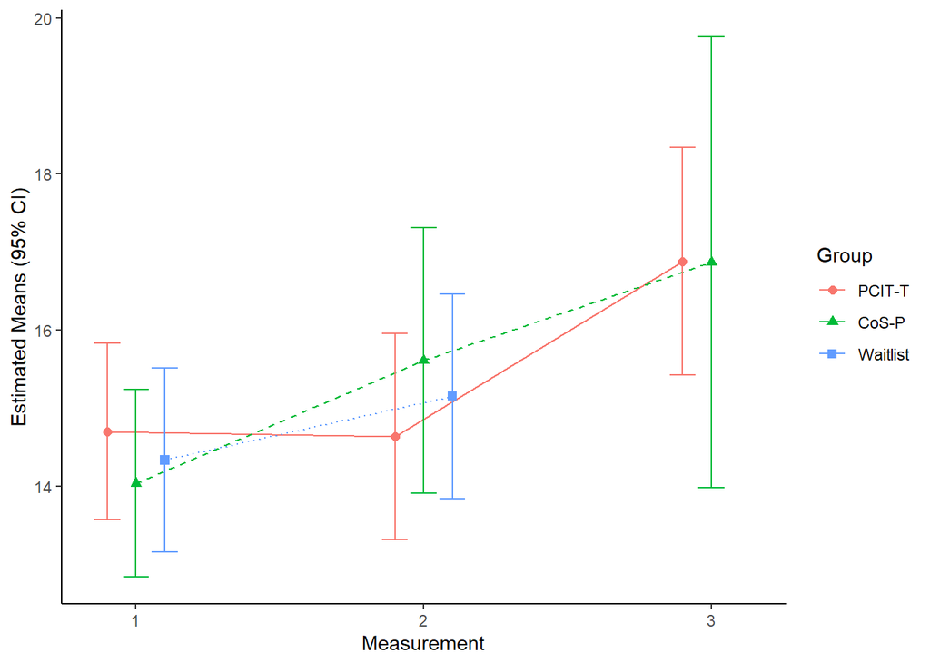

#### Hypothesis 1

We hypothesize that from baseline (‘T1’) to post-treatment/waitlist (‘T2’) there will be a gradient effect, whereby parent-child dyads who receive PCIT-T will show the greatest gains and parent-child dyads who receive no treatment will show the least gains. For the outcome, then, the null hypothesis is:

$H_0: \text {mean change}(\text{PCIT-T}) = \text {mean change}(\text{CoS-P}) = \text {mean change}(\text{Waitlist})$ $H_A: \text {mean change}(\text{PCIT-T}) > \text {mean change}(\text{CoS-P}) > \text {mean change}(\text{Waitlist})$

This is a joint hypothesis test.

First, confirming that the ordering of the means is as hypothesized:

```
## group = 1:
##  contrast estimate    SE    df t.ratio p.value
##  1 - 2      0.0637 0.752  84.3   0.085  0.9961
##  1 - 3     -2.1815 0.827  90.8  -2.638  0.0263
##  2 - 3     -2.2452 0.872  82.6  -2.574  0.0314
##
## group = 2:
##  contrast estimate    SE    df t.ratio p.value
##  1 - 2     -1.5749 0.935 108.1  -1.685  0.2156
##  1 - 3     -2.8352 1.497 127.3  -1.894  0.1447
##  2 - 3     -1.2603 1.587 112.0  -0.794  0.7074
##
## group = 3:
##  contrast estimate    SE    df t.ratio p.value
##  1 - 2     -0.8167 0.764  86.0  -1.069  0.5357
##  1 - 3      nonEst    NA    NA      NA      NA
##  2 - 3      nonEst    NA    NA      NA      NA
##
## Results are averaged over the levels of: asdcase
## Degrees-of-freedom method: kenward-roger
## P value adjustment: tukey method for comparing a family of 3 estimates
```

```
##   (Intercept) asdcase1 group2 group3 time2 time3 group2:time2 group3:time2
## 1           0        0      0      0     0     0           -1            0
## 2           0        0      0      0     0     1            0            1
##   group2:time3
## 1            0
## 2            0
```

```
##
##   General Linear Hypotheses
##
## Linear Hypotheses:
##        Estimate
## 1 == 0   -1.639
## 2 == 0    3.062
##
## Global Test:
##       F DF1 DF2  Pr(>F)
## 1 3.807   2 147 0.02444
```

#### Hypothesis 2

There will be a gradient of size of change from T2 to T3 such that the change in the PCIT-T group > the change in the CoS-P group. This isn’t really a gradient; it’s just 1 hypothesis.

First, the change in PCITT and COSP from time 2 to time 3:

```
## group = 1:
##  contrast estimate    SE    df t.ratio p.value
##  1 - 2      0.0637 0.752  84.3   0.085  0.9961
##  1 - 3     -2.1815 0.827  90.8  -2.638  0.0263
##  2 - 3     -2.2452 0.872  82.6  -2.574  0.0314
##
## group = 2:
##  contrast estimate    SE    df t.ratio p.value
##  1 - 2     -1.5749 0.935 108.1  -1.685  0.2156
##  1 - 3     -2.8352 1.497 127.3  -1.894  0.1447
##  2 - 3     -1.2603 1.587 112.0  -0.794  0.7074
##
## group = 3:
##  contrast estimate    SE    df t.ratio p.value
##  1 - 2     -0.8167 0.764  86.0  -1.069  0.5357
##  1 - 3      nonEst    NA    NA      NA      NA
##  2 - 3      nonEst    NA    NA      NA      NA
##
## Results are averaged over the levels of: asdcase
## Degrees-of-freedom method: kenward-roger
## P value adjustment: tukey method for comparing a family of 3 estimates
```

```
##
##   Simultaneous Tests for General Linear Hypotheses
##
## Fit: lmer(formula = outcome ~ asdcase + group * time + (1 | id), data = dat)
##
## Linear Hypotheses:
##        Estimate Std. Error z value Pr(>|z|)
## 1 == 0  -0.9849     1.7981  -0.548    0.584
## (Adjusted p values reported -- single-step method)
```

p>0.05.

#### Residuals

Assumptions of the model are met.

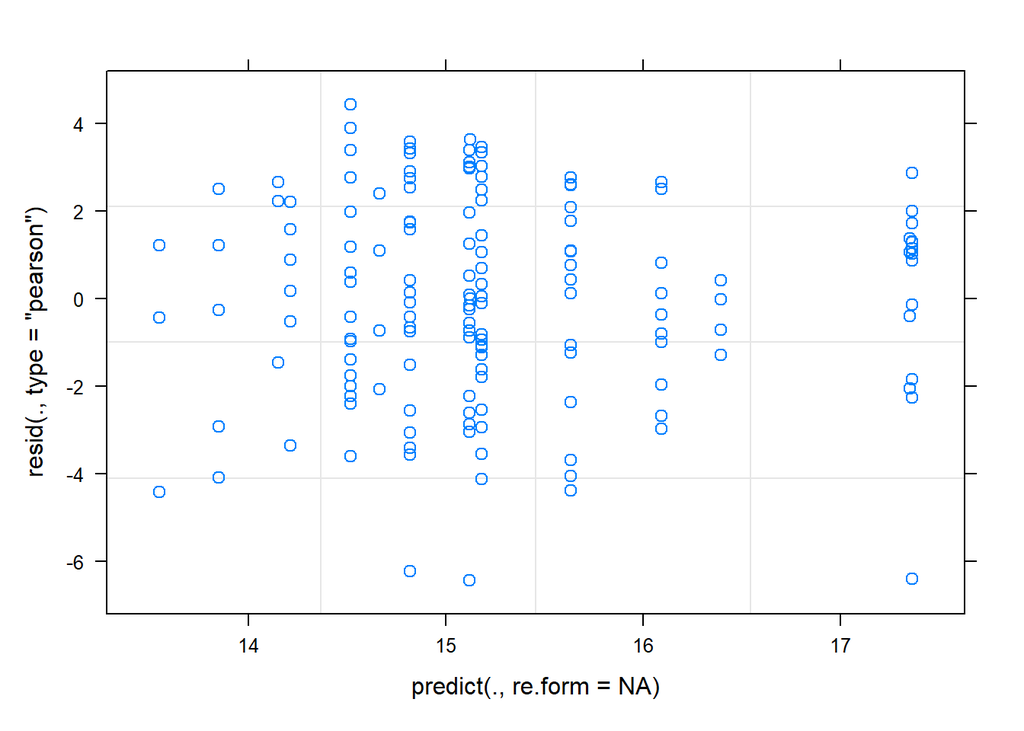

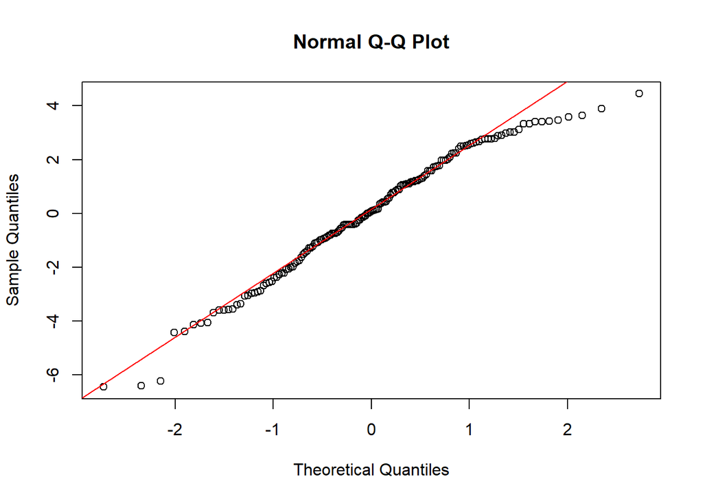

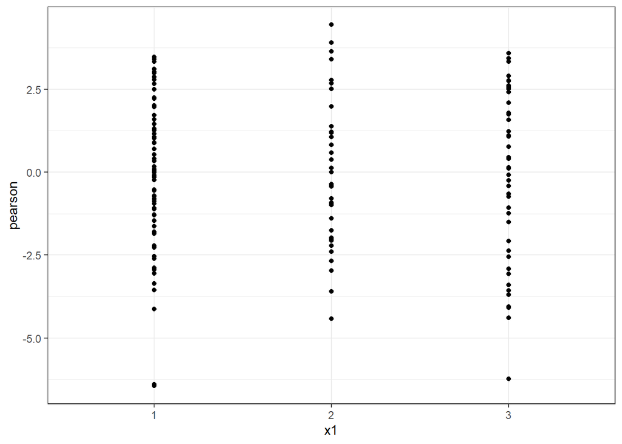

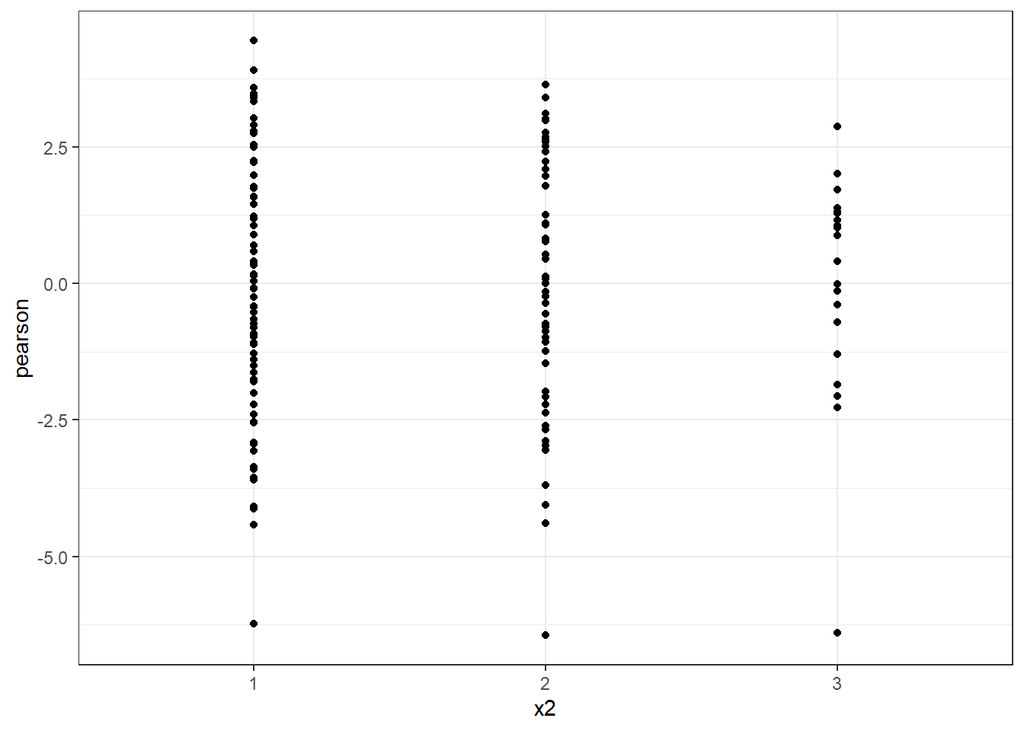

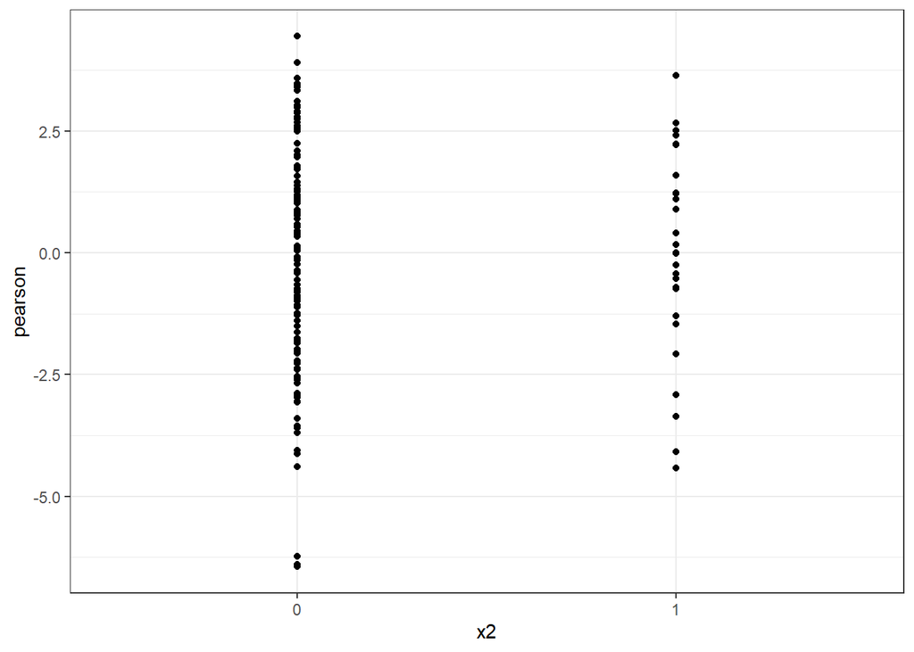

```r
rm(list = ls())
```